# scATAC-seq Rat Metrial Glands

Ha T. H. Vu

This is a documentation for analyses of scATAC-seq data, generated from rat metrial gland tissues on gestational day (GD) 15.5 and 19.5.

We first set up the environment with necessary libraries and functions.

```r
library(Signac)
library(Seurat)
library(S4Vectors)
library(GenomicRanges)
library(patchwork)
library(biomaRt)
library(ggplot2)

plotComparisonDf <- function(comparison_df, title){
  ggplot(comparison_df, aes(value)) +
    geom_histogram(bins = 70, aes(fill=method), color='black') +
    theme_classic() +
    scale_fill_manual(values=c("TF"="red", "log TF"="#d3d3d3")) +
    xlab('value in matrix') +
    facet_wrap(~method, scales='free') + ggtitle(title)
}
```

## 1. GD 15.5:

We first filter the low-quality cells, as determined in the previous step.

```r
set.seed(1234)

load("/work/LAS/geetu-lab/hhvu/project3_scATAC/scATAC-seq-analysis/1_preprocess/2_MACS2Peaks/3_unfilteredObjects-MACSpeaks/GD15.5_1.rda")
gd15.5_1 <- gd15.5_1_MACS
load("/work/LAS/geetu-lab/hhvu/project3_scATAC/scATAC-seq-analysis/1_preprocess/2_MACS2Peaks/3_unfilteredObjects-MACSpeaks/GD15.5_2.rda")
gd15.5_2 <- gd15.5_2_MACS
load("/work/LAS/geetu-lab/hhvu/project3_scATAC/scATAC-seq-analysis/1_preprocess/2_MACS2Peaks/3_unfilteredObjects-MACSpeaks/GD15.5_3.rda")
gd15.5_3 <- gd15.5_3_MACS

gd15.5_1 <- subset(x = gd15.5_1, subset =  peak_region_fragments > 1000 & peak_region_fragments < 20000 &  pct_reads_in_peaks > 15 & TSS.enrichment > 1.5)
gd15.5_2 <- subset(x = gd15.5_2, subset =  peak_region_fragments > 1000 & peak_region_fragments < 20000 &  pct_reads_in_peaks > 15 & TSS.enrichment > 1.5)
gd15.5_3 <- subset(x = gd15.5_3, subset =  peak_region_fragments > 1000 & peak_region_fragments < 20000 &  pct_reads_in_peaks > 15 & TSS.enrichment > 1.5)
```

Our data shows a trend of skewness; therefore, we should use `method = 3` when running dimension reduction. Codes here were adapted from http://andrewjohnhill.com/blog/2019/05/06/dimensionality-reduction-for-scatac-data/

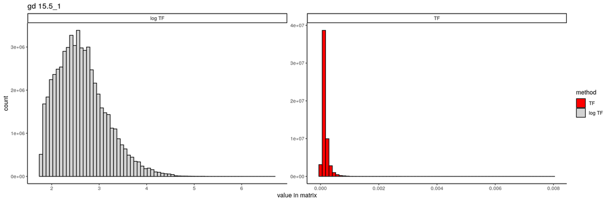

```r
counts <- gd15.5_1@assays$MACSpeaks@counts
tf = t(t(counts) / Matrix::colSums(counts))
comparison_df = rbind(data.frame(value=tf@x, method='TF'), data.frame(value=log1p(tf@x * 100000), method='log TF')) #100000 is scale factor, in Seurat it is default as 10000
plotComparisonDf(comparison_df, "gd 15.5_1")
```

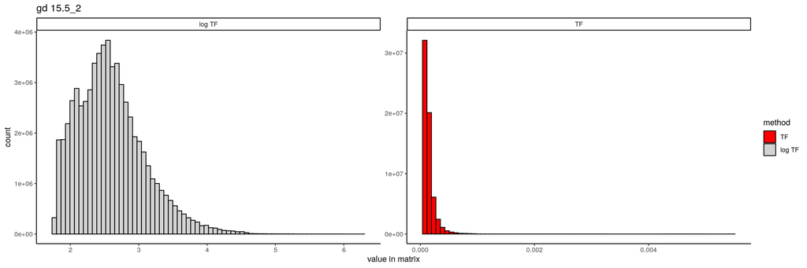

```r
counts <- gd15.5_2@assays$MACSpeaks@counts
tf = t(t(counts) / Matrix::colSums(counts))
comparison_df = rbind(data.frame(value=tf@x, method='TF'), data.frame(value=log1p(tf@x * 100000), method='log TF')) #100000 is scale factor, in Seurat it is default as 10000
plotComparisonDf(comparison_df, "gd 15.5_2")
```

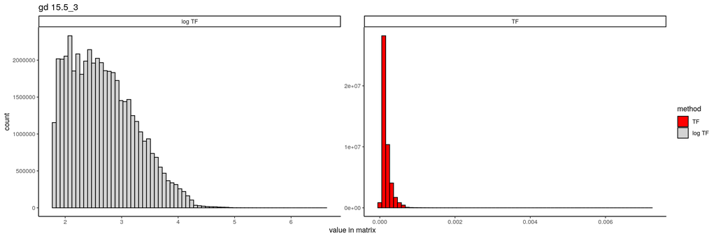

```r
counts <- gd15.5_3@assays$MACSpeaks@counts
tf = t(t(counts) / Matrix::colSums(counts))
comparison_df = rbind(data.frame(value=tf@x, method='TF'), data.frame(value=log1p(tf@x * 100000), method='log TF')) #100000 is scale factor, in Seurat it is default as 10000
plotComparisonDf(comparison_df, "gd 15.5_3")
```

Next, we run TF-IDF with `method = 3`.

```r
#run TF-IDF
gd15.5_1 <- RunTFIDF(gd15.5_1, assay = 'MACSpeaks', method = 3)
gd15.5_1 <- FindTopFeatures(gd15.5_1, min.cutoff = 'q0')
gd15.5_1 <- RunSVD(gd15.5_1, assay = 'MACSpeaks', reduction.key = 'LSI_', reduction.name = 'lsi')

gd15.5_2 <- RunTFIDF(gd15.5_2, assay = 'MACSpeaks', method = 3)
gd15.5_2 <- FindTopFeatures(gd15.5_2, min.cutoff = 'q0')
gd15.5_2 <- RunSVD(gd15.5_2, assay = 'MACSpeaks', reduction.key = 'LSI_', reduction.name = 'lsi')

gd15.5_3 <- RunTFIDF(gd15.5_3, assay = 'MACSpeaks', method = 3)
gd15.5_3 <- FindTopFeatures(gd15.5_3, min.cutoff = 'q0')
gd15.5_3 <- RunSVD(gd15.5_3, assay = 'MACSpeaks', reduction.key = 'LSI_', reduction.name = 'lsi')
```

We then look at the correlation between the LSI components and the sequencing depth, and the elbow plots, so that we can determine the number of components to keep for clustering.

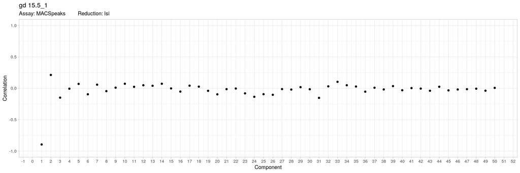

```r
DepthCor(gd15.5_1, n=50) + ggtitle("gd 15.5_1")
```

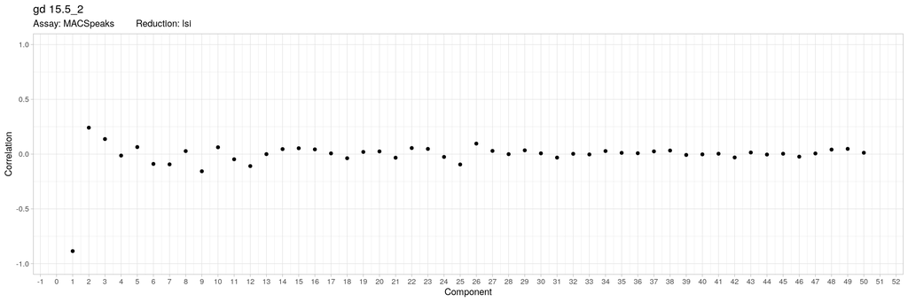

```r
DepthCor(gd15.5_2, n=50) + ggtitle("gd 15.5_2")
```

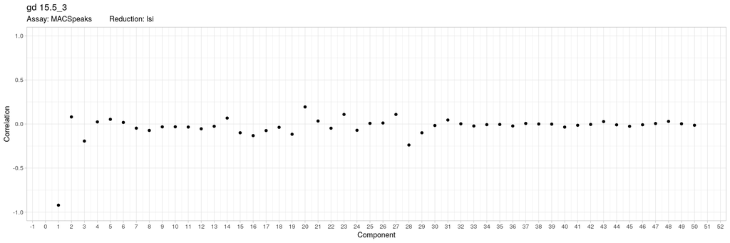

```r
DepthCor(gd15.5_3, n=50) + ggtitle("gd 15.5_3")
```

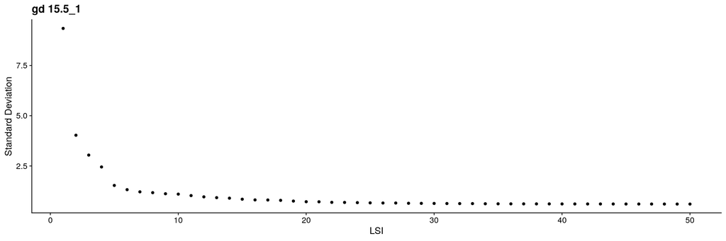

```r
ElbowPlot(gd15.5_1, n=50, reduction="lsi") + ggtitle("gd 15.5_1")
```

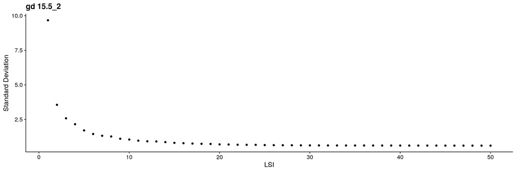

```r
ElbowPlot(gd15.5_2, n=50, reduction="lsi") + ggtitle("gd 15.5_2")
```

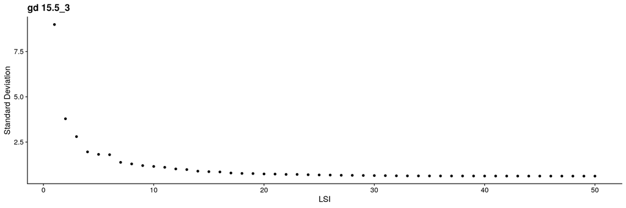

```r
ElbowPlot(gd15.5_3, n=50, reduction="lsi") + ggtitle("gd 15.5_3")
```

From the plots, we will keep the first 20 components, then exclude component 1 because of its high correlation with sequencing depth.

```r
gd15.5_1 <- RunUMAP(object = gd15.5_1, reduction = 'lsi', dims = 2:20) #drop the 1st component, see DepthCor plot and elbow plot
gd15.5_2 <- RunUMAP(object = gd15.5_2, reduction = 'lsi', dims = 2:20)
gd15.5_3 <- RunUMAP(object = gd15.5_3, reduction = 'lsi', dims = 2:20)
```

In order to merge the replicates, we need to find common peaks across replicates. We obtain this set of peaks here.

```r
intersecting.regions_15.5_2_3 <- findOverlaps(query = gd15.5_2, subject = gd15.5_3)
intersections.15.5_2 <- unique(queryHits(intersecting.regions_15.5_2_3))
peaks.15.5_2_3 <-  sort(granges(gd15.5_2)[intersections.15.5_2])
intersecting.regions_15.5_1_2_3 <- findOverlaps(query=gd15.5_1, subject=peaks.15.5_2_3)
intersections.15.5_1 <- unique(queryHits(intersecting.regions_15.5_1_2_3))
combined.peaks <- sort(granges(gd15.5_1)[intersections.15.5_1])
```

Next, we build a new Seurat object with the new peaks. It will require cell identities and fragment counts from each individual replicate.

```r
#load original cell identities
md.15.5_1 <- read.table(file = "/work/LAS/geetu-lab/hhvu/project3_scATAC/data/scATAC-seq/GD15.5/ATAC-15.5-1/singlecell.csv",
  stringsAsFactors = FALSE, sep = ",", header = TRUE, row.names = 1)[-1, ]

md.15.5_2 <- read.table(file = "/work/LAS/geetu-lab/hhvu/project3_scATAC/data/scATAC-seq/GD15.5/ATAC-15.5-2/singlecell.csv",
  stringsAsFactors = FALSE, sep = ",", header = TRUE, row.names = 1)[-1, ]

md.15.5_3 <- read.table(file = "/work/LAS/geetu-lab/hhvu/project3_scATAC/data/scATAC-seq/GD15.5/ATAC-15.5-3/singlecell.csv",
  stringsAsFactors = FALSE, sep = ",", header = TRUE, row.names = 1)[-1, ]

#load original fragment counts
frags.15.5_1 <- CreateFragmentObject(path = "/work/LAS/geetu-lab/hhvu/project3_scATAC/data/scATAC-seq/GD15.5/ATAC-15.5-1/fragments.tsv.gz",
  cells = rownames(md.15.5_1))

frags.15.5_2 <- CreateFragmentObject(path = "/work/LAS/geetu-lab/hhvu/project3_scATAC/data/scATAC-seq/GD15.5/ATAC-15.5-2/fragments.tsv.gz",
  cells = rownames(md.15.5_2))

frags.15.5_3 <- CreateFragmentObject(path = "/work/LAS/geetu-lab/hhvu/project3_scATAC/data/scATAC-seq/GD15.5/ATAC-15.5-3/fragments.tsv.gz",
  cells = rownames(md.15.5_3))

#count fragments in the common peaks among replicates
gd15.5_1_peaks <- FeatureMatrix(fragments=frags.15.5_1, features=combined.peaks, cells=colnames(gd15.5_1))
gd15.5_2_peaks <- FeatureMatrix(fragments=frags.15.5_2, features=combined.peaks, cells=colnames(gd15.5_2))
gd15.5_3_peaks <- FeatureMatrix(fragments=frags.15.5_3, features=combined.peaks, cells=colnames(gd15.5_3))

#build new assays to associate with the merged object
gd15.5_1_assay <- CreateChromatinAssay(counts = gd15.5_1_peaks, min.cells = 1, ranges = combined.peaks)
gd15.5_2_assay <- CreateChromatinAssay(counts = gd15.5_2_peaks, min.cells = 1, ranges = combined.peaks)
gd15.5_3_assay <- CreateChromatinAssay(counts = gd15.5_3_peaks, min.cells = 1, ranges = combined.peaks)

gd15.5_1[["combined"]] <- gd15.5_1_assay
gd15.5_2[["combined"]] <- gd15.5_2_assay
gd15.5_3[["combined"]] <- gd15.5_3_assay

DefaultAssay(gd15.5_1) <- "combined"
gd15.5_1 <- RunTFIDF(gd15.5_1, method=3)
gd15.5_1$dataset <- 'gd15.5_1'

DefaultAssay(gd15.5_2) <- "combined"
gd15.5_2 <- RunTFIDF(gd15.5_2, method=3)
gd15.5_2$dataset <- 'gd15.5_2'

DefaultAssay(gd15.5_3) <- "combined"
gd15.5_3 <- RunTFIDF(gd15.5_3, method=3)
gd15.5_3$dataset <- 'gd15.5_3'

#merge data
gd15.5combined <- merge(x = gd15.5_1, y = list(gd15.5_2, gd15.5_3), add.cell.ids = c("15.5_1", "15.5_2", "15.5_3"))

DefaultAssay(gd15.5combined) <- "combined"
gd15.5combined <- RunTFIDF(gd15.5combined, method=3)
gd15.5combined <- FindTopFeatures(gd15.5combined, min.cutoff = 'q0')
gd15.5combined <- RunSVD(gd15.5combined)
gd15.5combined <- RunUMAP(gd15.5combined, reduction = 'lsi', dims = 2:20)
```

With the new combined dataset, we need new fragment counts that are combined from the replicates. In BASH, carry out the following commands.

[output not shown]

```r
#build new Fragments() for the merge data
frag.path <- "/work/LAS/geetu-lab/hhvu/project3_scATAC/data/scATAC-seq/GD15.5/integratedFragments/fragments.tsv.gz"
fragments <- CreateFragmentObject(path = frag.path, cells = colnames(gd15.5combined), validate.fragments = TRUE)
Fragments(gd15.5combined) <- fragments

#cluster on the new merge data
gd15.5combined <- FindNeighbors(object = gd15.5combined, reduction = 'lsi', dims = 2:20)
gd15.5combined <- FindClusters(object = gd15.5combined, algorithm = 3, resolution = 0.8, verbose = FALSE)

#save(gd15.5combined, file="/work/LAS/geetu-lab/hhvu/project3_scATAC/scATAC-seq-analysis/2_mergedSamples/2_MACS2Peaks/15.5_1-2-3-merged.rda")
```

## 2. GD 19.5:

The analyses in this section is similar to those for gd 15.5 We first filter the low-quality cells.

```r
set.seed(1234)

load("/work/LAS/geetu-lab/hhvu/project3_scATAC/scATAC-seq-analysis/1_preprocess/2_MACS2Peaks/3_unfilteredObjects-MACSpeaks/GD19.5_4.rda")
gd19.5_4 <- gd19.5_4_MACS
load("/work/LAS/geetu-lab/hhvu/project3_scATAC/scATAC-seq-analysis/1_preprocess/2_MACS2Peaks/3_unfilteredObjects-MACSpeaks/GD19.5_5.rda")
gd19.5_5 <- gd19.5_5_MACS
load("/work/LAS/geetu-lab/hhvu/project3_scATAC/scATAC-seq-analysis/1_preprocess/2_MACS2Peaks/3_unfilteredObjects-MACSpeaks/GD19.5_6.rda")
gd19.5_6 <- gd19.5_6_MACS

gd19.5_4 <- subset(x = gd19.5_4, subset =  peak_region_fragments > 1000 & peak_region_fragments < 20000 &  pct_reads_in_peaks > 15 & TSS.enrichment > 1.5)
gd19.5_5 <- subset(x = gd19.5_5, subset =  peak_region_fragments > 1000 & peak_region_fragments < 20000 &  pct_reads_in_peaks > 15 & TSS.enrichment > 1.5)
gd19.5_6 <- subset(x = gd19.5_6, subset =  peak_region_fragments > 1000 & peak_region_fragments < 20000 &  pct_reads_in_peaks > 15 & TSS.enrichment > 1.5)
```

Our data shows a trend of skewness in the gd19.5 samples as well.

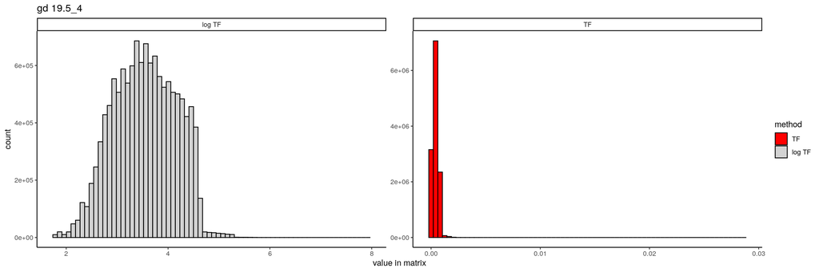

```r
counts <- gd19.5_4@assays$MACSpeaks@counts
tf = t(t(counts) / Matrix::colSums(counts))
comparison_df = rbind(data.frame(value=tf@x, method='TF'), data.frame(value=log1p(tf@x * 100000), method='log TF')) #100000 is scale factor, in Seurat it is default as 10000
plotComparisonDf(comparison_df, "gd 19.5_4")
```

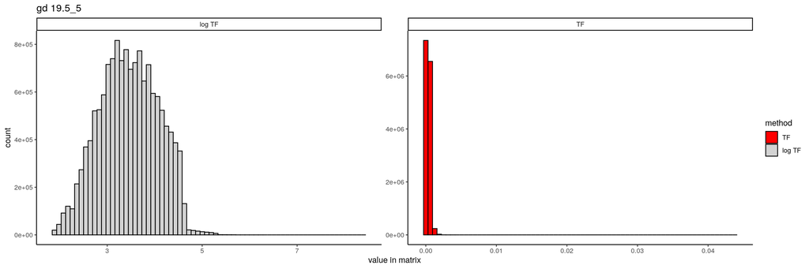

```r
counts <- gd19.5_5@assays$MACSpeaks@counts
tf = t(t(counts) / Matrix::colSums(counts))
comparison_df = rbind(data.frame(value=tf@x, method='TF'), data.frame(value=log1p(tf@x * 100000), method='log TF')) #100000 is scale factor, in Seurat it is default as 10000
plotComparisonDf(comparison_df, "gd 19.5_5")
```

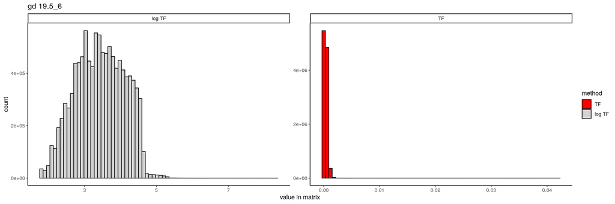

```r
counts <- gd19.5_6@assays$MACSpeaks@counts
tf = t(t(counts) / Matrix::colSums(counts))
comparison_df = rbind(data.frame(value=tf@x, method='TF'), data.frame(value=log1p(tf@x * 100000), method='log TF')) #100000 is scale factor, in Seurat it is default as 10000
plotComparisonDf(comparison_df, "gd 19.5_6")
```

Next, we run TF-IDF with `method = 3`.

```r
#run TF-IDF
gd19.5_4 <- RunTFIDF(gd19.5_4, assay = 'MACSpeaks', method = 3)
gd19.5_4 <- FindTopFeatures(gd19.5_4, min.cutoff = 'q0')
gd19.5_4 <- RunSVD(gd19.5_4, assay = 'MACSpeaks', reduction.key = 'LSI_', reduction.name = 'lsi')

gd19.5_5 <- RunTFIDF(gd19.5_5, assay = 'MACSpeaks', method = 3)
gd19.5_5 <- FindTopFeatures(gd19.5_5, min.cutoff = 'q0')
gd19.5_5 <- RunSVD(gd19.5_5, assay = 'MACSpeaks', reduction.key = 'LSI_', reduction.name = 'lsi')

gd19.5_6 <- RunTFIDF(gd19.5_6, assay = 'MACSpeaks', method = 3)
gd19.5_6 <- FindTopFeatures(gd19.5_6, min.cutoff = 'q0')
gd19.5_6 <- RunSVD(gd19.5_6, assay = 'MACSpeaks', reduction.key = 'LSI_', reduction.name = 'lsi')
```

We then look at the correlation between the LSI components and the sequencing depth, and the elbow plots, so that we can determine the number of components to keep for clustering.

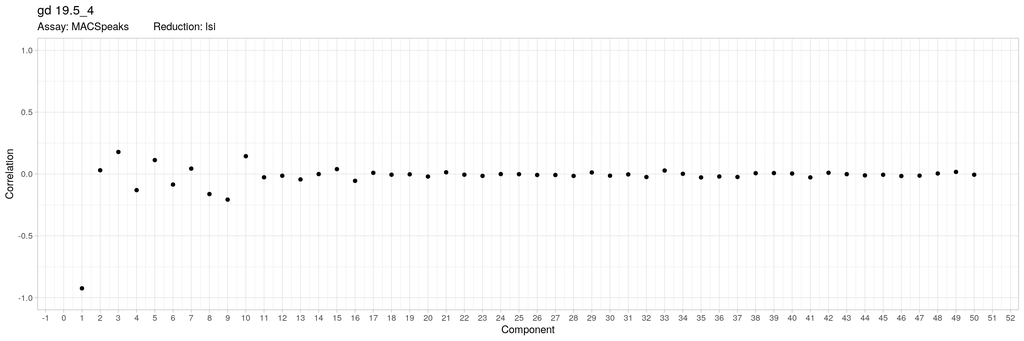

```r
DepthCor(gd19.5_4, n=50) + ggtitle("gd 19.5_4")
```

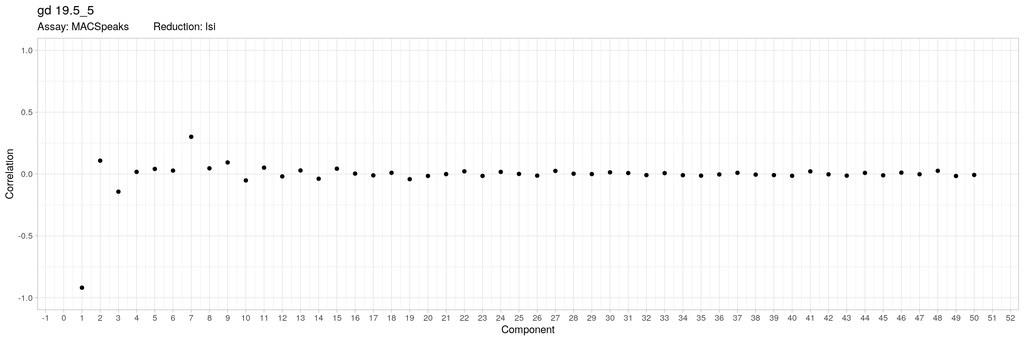

```r
DepthCor(gd19.5_5, n=50) + ggtitle("gd 19.5_5")
```

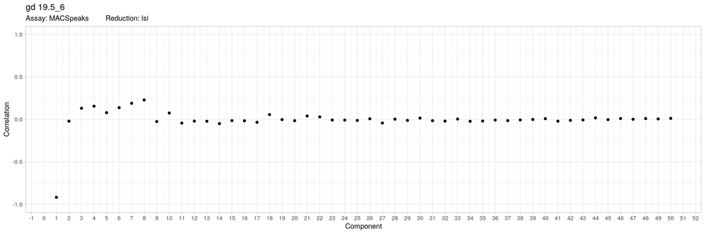

```r
DepthCor(gd19.5_6, n=50) + ggtitle("gd 19.5_6")
```

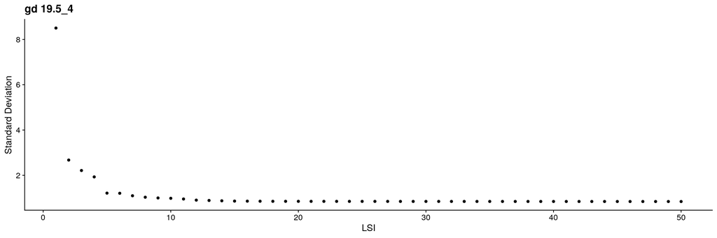

```r
ElbowPlot(gd19.5_4, n=50, reduction="lsi") + ggtitle("gd 19.5_4")
```

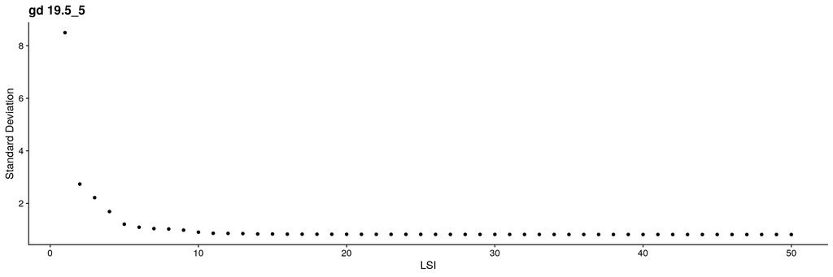

```r
ElbowPlot(gd19.5_5, n=50, reduction="lsi") + ggtitle("gd 19.5_5")
```

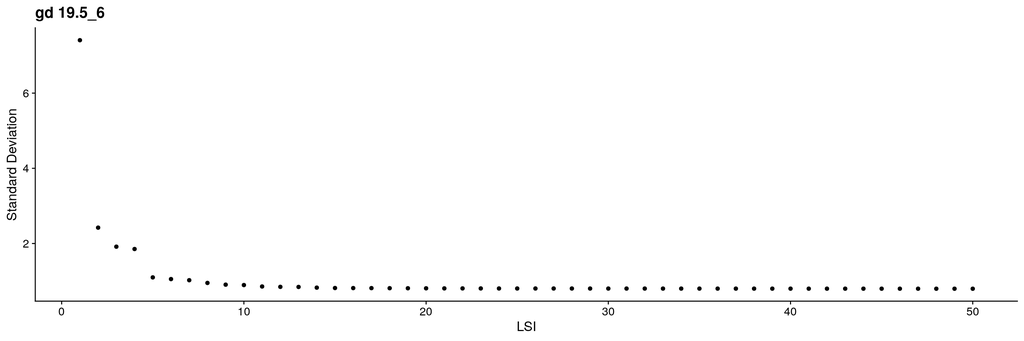

```r
ElbowPlot(gd19.5_6, n=50, reduction="lsi") + ggtitle("gd 19.5_6")
```

From the plots, we will keep the first 10 components, then exclude component 1 because of its high correlation with sequencing depth.

```r
gd19.5_4 <- RunUMAP(object = gd19.5_4, reduction = 'lsi', dims = 2:10) #drop the 1st component, see DepthCor plot and elbow plot
gd19.5_5 <- RunUMAP(object = gd19.5_5, reduction = 'lsi', dims = 2:10)
gd19.5_6 <- RunUMAP(object = gd19.5_6, reduction = 'lsi', dims = 2:10)
```

In order to merge the replicates, we need to find common peaks across replicates. We obtain this set of peaks here.

```r
intersecting.regions_19.5_5_6 <- findOverlaps(query = gd19.5_5, subject = gd19.5_6)
intersections.19.5_5 <- unique(queryHits(intersecting.regions_19.5_5_6))
peaks.19.5_5_6 <-  sort(granges(gd19.5_5)[intersections.19.5_5])
intersecting.regions_19.5_4_5_6 <- findOverlaps(query=gd19.5_4, subject=peaks.19.5_5_6)
intersections.19.5_4 <- unique(queryHits(intersecting.regions_19.5_4_5_6))
combined.peaks <- sort(granges(gd19.5_4)[intersections.19.5_4])
```

Next, we build a new Seurat object with the new peaks. It will require cell identities and fragment counts from each individual replicate.

```r
#load original cell identities
md.19.5_4 <- read.table(file = "/work/LAS/geetu-lab/hhvu/project3_scATAC/data/scATAC-seq/GD19.5/ATAC-19.5-4/singlecell.csv",
  stringsAsFactors = FALSE, sep = ",", header = TRUE, row.names = 1)[-1, ]

md.19.5_5 <- read.table(file = "/work/LAS/geetu-lab/hhvu/project3_scATAC/data/scATAC-seq/GD19.5/ATAC-19.5-5/singlecell.csv",
  stringsAsFactors = FALSE, sep = ",",  header = TRUE, row.names = 1)[-1, ]

md.19.5_6 <- read.table(file = "/work/LAS/geetu-lab/hhvu/project3_scATAC/data/scATAC-seq/GD19.5/ATAC-19.5-6/singlecell.csv",
  stringsAsFactors = FALSE, sep = ",",  header = TRUE,  row.names = 1)[-1, ]

#load original fragment counts
frags.19.5_4 <- CreateFragmentObject(path = "/work/LAS/geetu-lab/hhvu/project3_scATAC/data/scATAC-seq/GD19.5/ATAC-19.5-4/fragments.tsv.gz",
  cells = rownames(md.19.5_4))

frags.19.5_5 <- CreateFragmentObject(path = "/work/LAS/geetu-lab/hhvu/project3_scATAC/data/scATAC-seq/GD19.5/ATAC-19.5-5/fragments.tsv.gz",
  cells = rownames(md.19.5_5))

frags.19.5_6 <- CreateFragmentObject(path = "/work/LAS/geetu-lab/hhvu/project3_scATAC/data/scATAC-seq/GD19.5/ATAC-19.5-6/fragments.tsv.gz",
  cells = rownames(md.19.5_6))

#count fragments in the common peaks among replicates
gd19.5_4_peaks <- FeatureMatrix(fragments= frags.19.5_4, features=combined.peaks, cells=colnames(gd19.5_4))
gd19.5_5_peaks <- FeatureMatrix(fragments= frags.19.5_5, features=combined.peaks, cells=colnames(gd19.5_5))
gd19.5_6_peaks <- FeatureMatrix(fragments= frags.19.5_6, features=combined.peaks, cells=colnames(gd19.5_6))

#build new assays to associate with the merged object
gd19.5_4_assay <- CreateChromatinAssay(counts = gd19.5_4_peaks, min.cells = 1, ranges = combined.peaks)
gd19.5_5_assay <- CreateChromatinAssay(counts = gd19.5_5_peaks, min.cells = 1, ranges = combined.peaks)
gd19.5_6_assay <- CreateChromatinAssay(counts = gd19.5_6_peaks, min.cells = 1, ranges = combined.peaks)

gd19.5_4[["combined"]] <- gd19.5_4_assay
gd19.5_5[["combined"]] <- gd19.5_5_assay
gd19.5_6[["combined"]] <- gd19.5_6_assay

DefaultAssay(gd19.5_4) <- "combined"
gd19.5_4 <- RunTFIDF(gd19.5_4, method=3)
gd19.5_4$dataset <- 'gd19.5_4'

DefaultAssay(gd19.5_5) <- "combined"
gd19.5_5 <- RunTFIDF(gd19.5_5, method=3)
gd19.5_5$dataset <- 'gd19.5_5'

DefaultAssay(gd19.5_6) <- "combined"
gd19.5_6 <- RunTFIDF(gd19.5_6, method=3)
gd19.5_6$dataset <- 'gd19.5_6'

#merge data
gd19.5combined <- merge(x = gd19.5_4, y = list(gd19.5_5, gd19.5_6), add.cell.ids = c("19.5_4", "19.5_5", "19.5_6"))

DefaultAssay(gd19.5combined) <- "combined"
gd19.5combined <- RunTFIDF(gd19.5combined, method=3)
gd19.5combined <- FindTopFeatures(gd19.5combined, min.cutoff = 'q0')
gd19.5combined <- RunSVD(gd19.5combined)
gd19.5combined <- RunUMAP(gd19.5combined, reduction = 'lsi', dims = 2:10)
```

With the new combined dataset, we need new fragment counts that are combined from the replicates. In BASH, carry out the following commands.

[output not shown]

```r
#build new Fragments() for the merge data
frag.path <- "/work/LAS/geetu-lab/hhvu/project3_scATAC/data/scATAC-seq/GD19.5/integratedFragments/fragments.tsv.gz"
fragments <- CreateFragmentObject(path = frag.path, cells = colnames(gd19.5combined), validate.fragments = TRUE)
Fragments(gd19.5combined) <- fragments

#cluster on the new merge data
gd19.5combined <- FindNeighbors(object = gd19.5combined, reduction = 'lsi', dims = 2:10)
gd19.5combined <- FindClusters(object = gd19.5combined, algorithm = 3, resolution = 0.8, verbose = FALSE)

#save(gd19.5combined, file="/work/LAS/geetu-lab/hhvu/project3_scATAC/scATAC-seq-analysis/2_mergedSamples/2_MACS2Peaks/19.5_4-5-6-merged.rda")
```